# Data 621 Homework 3: Boston Crime Rates

Tommy Jenkins, Violeta Stoyanova, Todd Weigel, Peter Kowalchuk, Eleanor R-Secoquian

October, 2019

# 1 OVERVIEW

In this homework assignment, we will explore, analyze and model a data set containing information on crime for various neighborhoods of a major city. Each record has a response variable indicating whether or not the crime rate is above the median crime rate (1) or not (0).

## 1.1 Objective:

The objective is to build a binary logistic regression model on the training data set to predict whether the neighborhood will be at risk for high crime levels.

# 2 DATA EXPLORATION

## 2.1 Data Summary

The dataset consists of two data files: training and evaluation. The training dataset contains 13 columns, while the evaluation dataset contains 12. The evaluation dataset is missing column target which represend our responce variable and defines whether the crime rate is above the median crime rate (1) or not (0). We will start by exploring the training data set since it will be the one used to generate the regression model.

First we see that all data is numeric. The dataset does contain one dummy variable to identify if the property borders the Charles River (1) or not (0).

An important aspect of any dataset is to determine how much, if any, data is missing. We look at all the variables to see which if any have missing data. We look at the basic descriptive statistics as well as the missing data and their percentages:

|  | vars | n | mean | sd | median | trimmed | mad | min | max | range | skew | kurtosis | se | na_count | na_count_perc |
| --- | --- | --- | --- | --- | --- | --- | --- | --- | --- | --- | --- | --- | --- | --- | --- |
| zn | 1 | 466 | 11.5772532 | 23.3646511 | 0.00000 | 5.3542781 | 0.0000000 | 0.0000 | 100.0000 | 100.0000 | 2.1768152 | 3.8135765 | 1.0823466 | 0 | 0 |
| indus | 2 | 466 | 11.1050215 | 6.8458549 | 9.69000 | 10.9082353 | 9.3403800 | 0.4600 | 27.7400 | 27.2800 | 0.2885450 | -1.2432132 | 0.3171281 | 0 | 0 |
| chas | 3 | 466 | 0.0708155 | 0.2567920 | 0.00000 | 0.0000000 | 0.0000000 | 0.0000 | 1.0000 | 1.0000 | 3.3354899 | 9.1451313 | 0.0118957 | 0 | 0 |
| nox | 4 | 466 | 0.5543105 | 0.1166667 | 0.53800 | 0.5442684 | 0.1334340 | 0.3890 | 0.8710 | 0.4820 | 0.7463281 | -0.0357736 | 0.0054045 | 0 | 0 |
| rm | 5 | 466 | 6.2906738 | 0.7048513 | 6.21000 | 6.2570615 | 0.5166861 | 3.8630 | 8.7800 | 4.9170 | 0.4793202 | 1.5424378 | 0.0326516 | 0 | 0 |
| age | 6 | 466 | 68.3675966 | 28.3213784 | 77.15000 | 70.9553476 | 30.0226500 | 2.9000 | 100.0000 | 97.1000 | -0.5777075 | -1.0098814 | 1.3119625 | 0 | 0 |
| dis | 7 | 466 | 3.7956929 | 2.1069496 | 3.19095 | 3.5443647 | 1.9144814 | 1.1296 | 12.1265 | 10.9969 | 0.9988926 | 0.4719679 | 0.0976026 | 0 | 0 |
| rad | 8 | 466 | 9.5300429 | 8.6859272 | 5.00000 | 8.6978610 | 1.4826000 | 1.0000 | 24.0000 | 23.0000 | 1.0102788 | -0.8619110 | 0.4023678 | 0 | 0 |
| tax | 9 | 466 | 409.5021459 | 167.9000887 | 334.50000 | 401.5080214 | 104.5233000 | 187.0000 | 711.0000 | 524.0000 | 0.6593136 | -1.1480456 | 7.7778214 | 0 | 0 |
| ptratio | 10 | 466 | 18.3984979 | 2.1968447 | 18.90000 | 18.5970588 | 1.9273800 | 12.6000 | 22.0000 | 9.4000 | -0.7542681 | -0.4003627 | 0.1017669 | 0 | 0 |
| lstat | 11 | 466 | 12.6314592 | 7.1018907 | 11.35000 | 11.8809626 | 7.0720020 | 1.7300 | 37.9700 | 36.2400 | 0.9055864 | 0.5033688 | 0.3289887 | 0 | 0 |
| medv | 12 | 466 | 22.5892704 | 9.2396814 | 21.20000 | 21.6304813 | 6.0045300 | 5.0000 | 50.0000 | 45.0000 | 1.0766920 | 1.3737825 | 0.4280200 | 0 | 0 |
| target | 13 | 466 | 0.4914163 | 0.5004636 | 0.00000 | 0.4893048 | 0.0000000 | 0.0000 | 1.0000 | 1.0000 | 0.0342293 | -2.0031131 | 0.0231835 | 0 | 0 |

zn indus chas nox rm age dis rad tax 0 0 0 0 0 0 0 0 0 ptratio lstat medv target 0 0 0 0

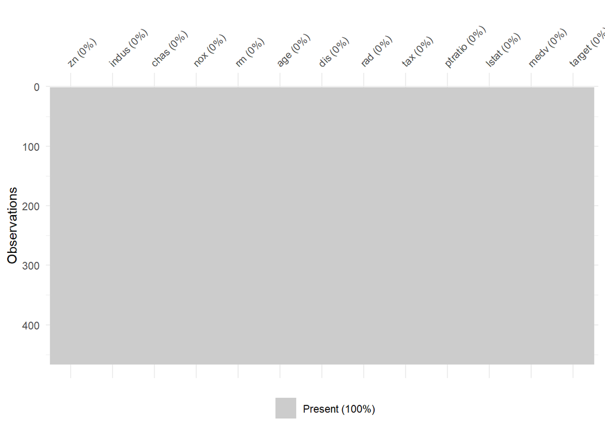

zn indus chas nox rm age dis rad tax ptratio lstat medv target 1 0 19.58 0 0.605 7.929 96.2 2.0459 5 403 14.7 3.70 50.0 1 2 0 19.58 1 0.871 5.403 100.0 1.3216 5 403 14.7 26.82 13.4 1 3 0 18.10 0 0.740 6.485 100.0 1.9784 24 666 20.2 18.85 15.4 1 4 30 4.93 0 0.428 6.393 7.8 7.0355 6 300 16.6 5.19 23.7 0 5 0 2.46 0 0.488 7.155 92.2 2.7006 3 193 17.8 4.82 37.9 0 6 0 8.56 0 0.520 6.781 71.3 2.8561 5 384 20.9 7.67 26.5 0

## 2.2 Missing and Invalid Data

No missing data was found in the dataset.

With missing data assessed, we can look into the data in more detail. To visualize this we plot histograms for each data. Several predictors like dist, chas, rad, zn and tax are not normally distributed and noticable outliers.

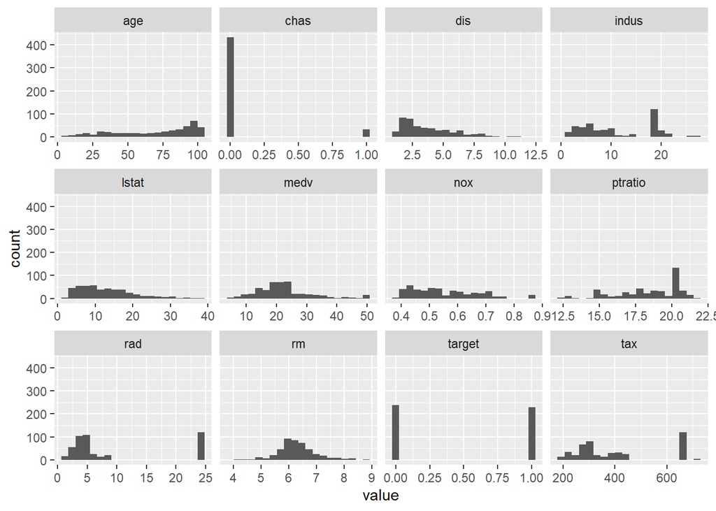

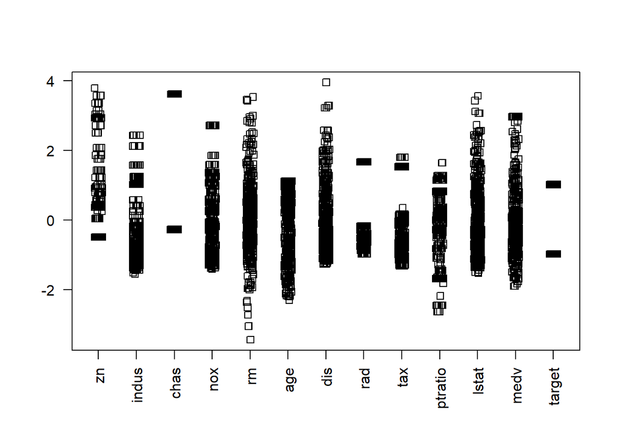

# 3 DATA PREPARATION

## 3.1 Fix missing values

No data was found missing.

## 3.2 Mathematical transformations.

$zn Box-Cox Transformation

466 data points used to estimate Lambda

Input data summary: Min. 1st Qu. Median Mean 3rd Qu. Max. 0.00 0.00 0.00 11.58 16.25 100.00

Lambda could not be estimated; no transformation is applied

$indus Box-Cox Transformation

466 data points used to estimate Lambda

Input data summary: Min. 1st Qu. Median Mean 3rd Qu. Max. 0.460 5.145 9.690 11.105 18.100 27.740

Largest/Smallest: 60.3 Sample Skewness: 0.289

Estimated Lambda: 0.4

$chas Box-Cox Transformation

466 data points used to estimate Lambda

Input data summary: Min. 1st Qu. Median Mean 3rd Qu. Max. 0.00000 0.00000 0.00000 0.07082 0.00000 1.00000

Lambda could not be estimated; no transformation is applied

$nox Box-Cox Transformation

466 data points used to estimate Lambda

Input data summary: Min. 1st Qu. Median Mean 3rd Qu. Max. 0.3890 0.4480 0.5380 0.5543 0.6240 0.8710

Largest/Smallest: 2.24 Sample Skewness: 0.746

Estimated Lambda: -0.9

$rm Box-Cox Transformation

466 data points used to estimate Lambda

Input data summary: Min. 1st Qu. Median Mean 3rd Qu. Max. 3.863 5.887 6.210 6.291 6.630 8.780

Largest/Smallest: 2.27 Sample Skewness: 0.479

Estimated Lambda: 0.2

$age Box-Cox Transformation

466 data points used to estimate Lambda

Input data summary: Min. 1st Qu. Median Mean 3rd Qu. Max. 2.90 43.88 77.15 68.37 94.10 100.00

Largest/Smallest: 34.5 Sample Skewness: -0.578

Estimated Lambda: 1.3

$dis Box-Cox Transformation

466 data points used to estimate Lambda

Input data summary: Min. 1st Qu. Median Mean 3rd Qu. Max. 1.130 2.101 3.191 3.796 5.215 12.127

Largest/Smallest: 10.7 Sample Skewness: 0.999

Estimated Lambda: -0.1 With fudge factor, Lambda = 0 will be used for transformations

$rad Box-Cox Transformation

466 data points used to estimate Lambda

Input data summary: Min. 1st Qu. Median Mean 3rd Qu. Max. 1.00 4.00 5.00 9.53 24.00 24.00

Largest/Smallest: 24 Sample Skewness: 1.01

Estimated Lambda: -0.2 With fudge factor, Lambda = 0 will be used for transformations

$tax Box-Cox Transformation

466 data points used to estimate Lambda

Input data summary: Min. 1st Qu. Median Mean 3rd Qu. Max. 187.0 281.0 334.5 409.5 666.0 711.0

Largest/Smallest: 3.8 Sample Skewness: 0.659

Estimated Lambda: -0.5

$ptratio Box-Cox Transformation

466 data points used to estimate Lambda

Input data summary: Min. 1st Qu. Median Mean 3rd Qu. Max. 12.6 16.9 18.9 18.4 20.2 22.0

Largest/Smallest: 1.75 Sample Skewness: -0.754

Estimated Lambda: 2

$lstat Box-Cox Transformation

466 data points used to estimate Lambda

Input data summary: Min. 1st Qu. Median Mean 3rd Qu. Max. 1.730 7.043 11.350 12.631 16.930 37.970

Largest/Smallest: 21.9 Sample Skewness: 0.906

Estimated Lambda: 0.2

$medv Box-Cox Transformation

466 data points used to estimate Lambda

Input data summary: Min. 1st Qu. Median Mean 3rd Qu. Max. 5.00 17.02 21.20 22.59 25.00 50.00

Largest/Smallest: 10 Sample Skewness: 1.08

Estimated Lambda: 0.2

$target Box-Cox Transformation

466 data points used to estimate Lambda

Input data summary: Min. 1st Qu. Median Mean 3rd Qu. Max. 0.0000 0.0000 0.0000 0.4914 1.0000 1.0000

Lambda could not be estimated; no transformation is applied

## 3.3 Variable Creation / Removal

```
  indus       chas       nox         rm       age        dis
```

[1,] 0.6048507 0.08004187 0.7261062 -0.1525533 0.6301062 -0.6186731 rad tax ptratio lstat medv target [1,] 0.6281049 0.6111133 0.2508489 0.469127 -0.2705507 1

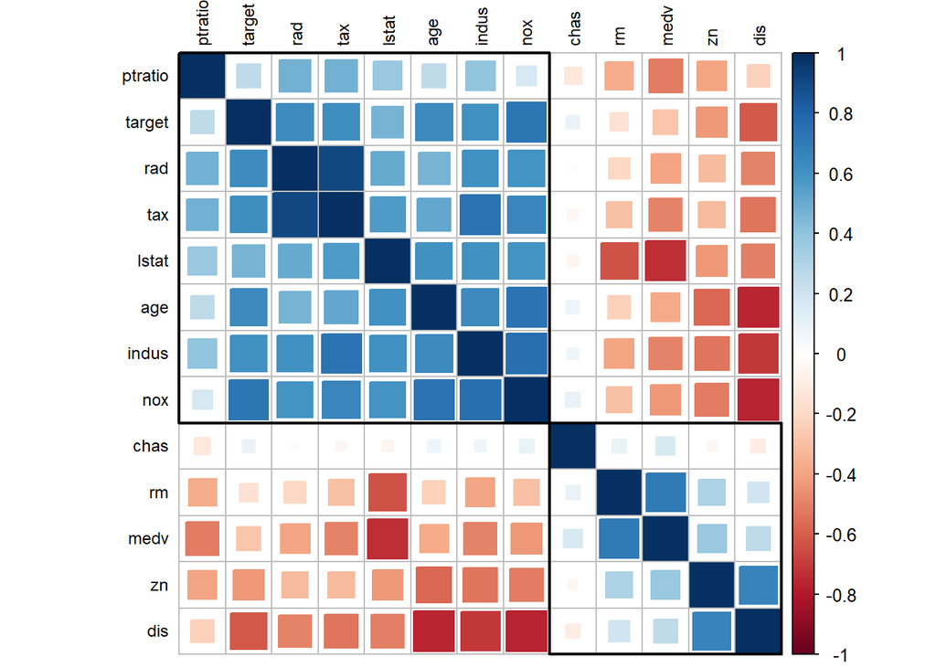

# 4 BUILD MODELS

### 4.0.1 General regression

We start by building a model with all the predictors in the dataset.

Call: glm(formula = target ~ ., family = binomial(link = “logit”), data = crimeTrain)

Deviance Residuals: Min 1Q Median 3Q Max  
-1.8464 -0.1445 -0.0017 0.0029 3.4665

Coefficients: Estimate Std. Error z value Pr(>|z|)  
(Intercept) -40.822934 6.632913 -6.155 7.53e-10 zn -0.065946 0.034656 -1.903 0.05706 .  
indus -0.064614 0.047622 -1.357 0.17485  
chas 0.910765 0.755546 1.205 0.22803  
nox 49.122297 7.931706 6.193 5.90e-10 rm -0.587488 0.722847 -0.813 0.41637  
age 0.034189 0.013814 2.475 0.01333 *  
dis 0.738660 0.230275 3.208 0.00134 ** rad 0.666366 0.163152 4.084 4.42e-05 *tax -0.006171 0.002955 -2.089 0.03674*  
ptratio 0.402566 0.126627 3.179 0.00148 lstat 0.045869 0.054049 0.849 0.39608  
medv 0.180824 0.068294 2.648 0.00810 ** — Signif. codes: 0 ‘**’ 0.001 ’**’ 0.01 ’’ 0.05 ‘.’ 0.1 ’ ’ 1

(Dispersion parameter for binomial family taken to be 1)

Null deviance: 645.88 on 465 degrees of freedom Residual deviance: 192.05 on 453 degrees of freedom AIC: 218.05

Number of Fisher Scoring iterations: 9

The Summary of this model shows several predictor are not relevant. We build a second model without these predictors.

Call: glm(formula = target ~ nox + age + dis + rad + tax + ptratio + medv, family = binomial(link = “logit”), data = crimeTrain)

Deviance Residuals: Min 1Q Median 3Q Max  
-2.01059 -0.19744 -0.01371 0.00402 3.06424

Coefficients: Estimate Std. Error z value Pr(>|z|)  
(Intercept) -36.824228 5.858405 -6.286 3.26e-10 *nox 42.338378 6.639207 6.377 1.81e-10* age 0.031882 0.010693 2.982 0.002867 ** dis 0.429555 0.171849 2.500 0.012433 *  
rad 0.701767 0.139426 5.033 4.82e-07 **tax -0.008237 0.002534 -3.250 0.001153** ptratio 0.376575 0.108912 3.458 0.000545 **medv 0.093653 0.033556 2.791 0.005255** — Signif. codes: 0 ‘**’ 0.001 ’**’ 0.01 ’’ 0.05 ‘.’ 0.1 ’ ’ 1

(Dispersion parameter for binomial family taken to be 1)

Null deviance: 645.88 on 465 degrees of freedom Residual deviance: 203.45 on 458 degrees of freedom AIC: 219.45

Number of Fisher Scoring iterations: 9

[1] 1 [1] 1

### 4.0.2 AIC Step Method

Another way of selecting which predictors to use in the model is by calculating the AIC of the model. This metric is similar to the adjusted R-square of a model in that it penalizes models with more predictors over simpler model with few predictors. We use Stepwise function in r to find the lowest AIC with different predictors.

Start: AIC=218.05 target ~ zn + indus + chas + nox + rm + age + dis + rad + tax + ptratio + lstat + medv

```
   Df Deviance    AIC
```

- rm 1 192.71 216.71
- lstat 1 192.77 216.77
- chas 1 193.53 217.53
- indus 1 193.99 217.99 192.05 218.05
- tax 1 196.59 220.59
- zn 1 196.89 220.89
- age 1 198.73 222.73
- medv 1 199.95 223.95
- ptratio 1 203.32 227.32
- dis 1 203.84 227.84
- rad 1 233.74 257.74
- nox 1 265.05 289.05

Step: AIC=216.71 target ~ zn + indus + chas + nox + age + dis + rad + tax + ptratio + lstat + medv

```
   Df Deviance    AIC
```

- chas 1 194.24 216.24
- lstat 1 194.32 216.32
- indus 1 194.58 216.58 192.71 216.71
- tax 1 197.59 219.59
- zn 1 198.07 220.07
- age 1 199.11 221.11
- ptratio 1 203.53 225.53
- dis 1 203.85 225.85
- medv 1 205.35 227.35
- rad 1 233.81 255.81
- nox 1 265.14 287.14

Step: AIC=216.24 target ~ zn + indus + nox + age + dis + rad + tax + ptratio + lstat + medv

```
   Df Deviance    AIC
```

- indus 1 195.51 215.51 194.24 216.24
- lstat 1 196.33 216.33
- zn 1 200.59 220.59
- tax 1 200.75 220.75
- age 1 201.00 221.00
- ptratio 1 203.94 223.94
- dis 1 204.83 224.83
- medv 1 207.12 227.12
- rad 1 241.41 261.41
- nox 1 265.19 285.19

Step: AIC=215.51 target ~ zn + nox + age + dis + rad + tax + ptratio + lstat + medv

```
   Df Deviance    AIC
```

- lstat 1 197.32 215.32 195.51 215.51
- zn 1 202.05 220.05
- age 1 202.23 220.23
- ptratio 1 205.01 223.01
- dis 1 205.96 223.96
- tax 1 206.60 224.60
- medv 1 208.13 226.13
- rad 1 249.55 267.55
- nox 1 270.59 288.59

Step: AIC=215.32 target ~ zn + nox + age + dis + rad + tax + ptratio + medv

```
   Df Deviance    AIC
```

197.32 215.32 - zn 1 203.45 219.45 - ptratio 1 206.27 222.27 - age 1 207.13 223.13 - tax 1 207.62 223.62 - dis 1 207.64 223.64 - medv 1 208.65 224.65 - rad 1 250.98 266.98 - nox 1 273.18 289.18

Call: glm(formula = target ~ zn + nox + age + dis + rad + tax + ptratio + medv, family = binomial(link = “logit”), data = crimeTrain)

Deviance Residuals: Min 1Q Median 3Q Max  
-1.8295 -0.1752 -0.0021 0.0032 3.4191

Coefficients: Estimate Std. Error z value Pr(>|z|)  
(Intercept) -37.415922 6.035013 -6.200 5.65e-10 *zn -0.068648 0.032019 -2.144 0.03203*  
nox 42.807768 6.678692 6.410 1.46e-10 *age 0.032950 0.010951 3.009 0.00262 **dis 0.654896 0.214050 3.060 0.00222** rad 0.725109 0.149788 4.841 1.29e-06* **tax -0.007756 0.002653 -2.924 0.00346** ptratio 0.323628 0.111390 2.905 0.00367 ** medv 0.110472 0.035445 3.117 0.00183 ** — Signif. codes: 0 ‘**’ 0.001 ’**’ 0.01 ’’ 0.05 ‘.’ 0.1 ’ ’ 1

(Dispersion parameter for binomial family taken to be 1)

Null deviance: 645.88 on 465 degrees of freedom Residual deviance: 197.32 on 457 degrees of freedom AIC: 215.32

Number of Fisher Scoring iterations: 9

This reduces the predictors used in the model to these: zn nox age dis rad tax ptRation medv

The AIC improves marginally from 218.05 (our original general model) to 215.32, but we also benefit by having a simpler model less prone to overfitting.

Also, the predictors in the model now are all signficant (under 0.05 pr level) and all but one under .01 or very significant. Which is much improved over the prior model

### 4.0.3 BIC Method

To determine the number of predictors and which predictors to be used we will use the Bayesian Information Criterion (BIC).

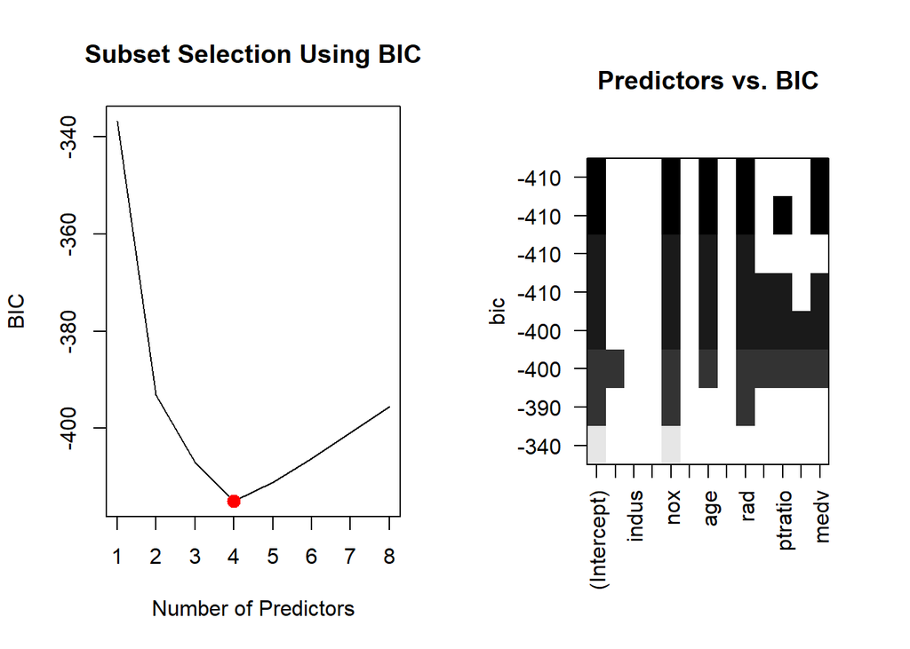

The plot on the right shows that the number of predictors with the lowest BIC are `nox` , `age`, `rad`, and `medv`. We will use those predictors to build the next model

|  | Estimate | Std. Error | z value | Pr(>\|z\|) |
| --- | --- | --- | --- | --- |
| **(Intercept)** | -17.63 | 2.168 | -8.131 | 4.246e-16 |
| **nox** | 23.62 | 3.936 | 6.003 | 1.942e-09 |
| **age** | 0.01824 | 0.009172 | 1.989 | 0.04673 |
| **rad** | 0.4528 | 0.1093 | 4.144 | 3.413e-05 |
| **medv** | 0.04481 | 0.02319 | 1.932 | 0.05338 |

(Dispersion parameter for binomial family taken to be 1 )

| Null deviance: | 645.9 on 465 degrees of freedom |
| --- | --- |
| Residual deviance: | 232.8 on 461 degrees of freedom |

### 4.0.4 Forward Selection Method using some BoxCox transformed independent variables:

Start: AIC=680.3 target ~ 1

```
         Df Deviance    AIC
```

- I(nox^-1) 1 50.349 291.51
- I(age^2) 1 66.713 422.64
- I(dis^-0.5) 1 66.801 423.26
- rad 1 70.518 448.50
- I(log(indus)) 1 74.068 471.38
- I(tax^-1) 1 74.547 474.39
- lstat 1 90.834 566.47
- zn 1 94.762 586.20
- I(ptratio^2) 1 107.479 644.88
- medv 1 107.941 646.88
- I(log(rm)) 1 112.912 667.86
- I(sqrt(chas)) 1 115.720 679.31 116.466 680.30

Step: AIC=291.51 target ~ I(nox^-1)

```
         Df Deviance    AIC
```

- rad 1 45.272 243.97
- I(tax^-1) 1 46.956 260.99
- I(age^2) 1 49.650 286.99
- I(ptratio^2) 1 49.778 288.19
- I(log(rm)) 1 49.876 289.10
- medv 1 49.907 289.40
- I(log(indus)) 1 50.043 290.66 50.349 291.51
- zn 1 50.147 291.63
- I(sqrt(chas)) 1 50.305 293.10
- lstat 1 50.336 293.38
- I(dis^-0.5) 1 50.345 293.46

Step: AIC=243.97 target ~ I(nox^-1) + rad

```
         Df Deviance    AIC
```

- medv 1 44.061 233.33
- I(age^2) 1 44.442 237.35
- I(log(rm)) 1 44.674 239.77
- I(tax^-1) 1 45.017 243.34 45.272 243.97
- I(sqrt(chas)) 1 45.113 244.33
- lstat 1 45.149 244.71
- I(dis^-0.5) 1 45.180 245.03
- zn 1 45.223 245.47
- I(ptratio^2) 1 45.240 245.64
- I(log(indus)) 1 45.267 245.92

Step: AIC=233.33 target ~ I(nox^-1) + rad + medv

```
         Df Deviance    AIC
```

- I(age^2) 1 43.027 224.27
- I(tax^-1) 1 43.368 227.96
- I(dis^-0.5) 1 43.827 232.86
- lstat 1 43.834 232.93
- I(log(indus)) 1 43.856 233.17 44.061 233.33
- I(ptratio^2) 1 43.956 234.23
- I(sqrt(chas)) 1 44.030 235.01
- I(log(rm)) 1 44.052 235.24
- zn 1 44.060 235.33

Step: AIC=224.27 target ~ I(nox^-1) + rad + medv + I(age^2)

```
         Df Deviance    AIC
```

- I(dis^-0.5) 1 42.184 217.05
- I(tax^-1) 1 42.397 219.40 43.027 224.27
- I(log(indus)) 1 42.888 224.77
- I(ptratio^2) 1 42.975 225.71
- I(sqrt(chas)) 1 43.004 226.02
- lstat 1 43.006 226.05
- zn 1 43.013 226.12
- I(log(rm)) 1 43.024 226.24

Step: AIC=217.05 target ~ I(nox^-1) + rad + medv + I(age^2) + I(dis^-0.5)

```
         Df Deviance    AIC
```

- I(tax^-1) 1 41.399 210.29
- I(log(indus)) 1 41.866 215.53 42.184 217.05
- lstat 1 42.036 217.41
- I(ptratio^2) 1 42.124 218.39
- I(log(rm)) 1 42.150 218.67
- I(sqrt(chas)) 1 42.169 218.89
- zn 1 42.173 218.93

Step: AIC=210.29 target ~ I(nox^-1) + rad + medv + I(age^2) + I(dis^-0.5) + I(tax^-1)

```
         Df Deviance    AIC
```

- lstat 1 41.180 209.83 41.399 210.29
- I(log(indus)) 1 41.232 210.42
- I(ptratio^2) 1 41.318 211.38
- I(log(rm)) 1 41.360 211.86
- I(sqrt(chas)) 1 41.374 212.02
- zn 1 41.396 212.27

Step: AIC=209.83 target ~ I(nox^-1) + rad + medv + I(age^2) + I(dis^-0.5) + I(tax^-1) + lstat

```
         Df Deviance    AIC
```

41.180 209.83 + I(log(indus)) 1 41.012 209.92 + I(ptratio^2) 1 41.062 210.49 + I(sqrt(chas)) 1 41.159 211.59 + zn 1 41.174 211.76 + I(log(rm)) 1 41.178 211.80

Call: glm(formula = target ~ I(nox^-1) + rad + medv + I(age^2) + I(dis^-0.5) + I(tax^-1) + lstat, data = crimeTrain)

Deviance Residuals: Min 1Q Median 3Q Max  
-0.70627 -0.18647 -0.02143 0.13160 0.98687

Coefficients: Estimate Std. Error t value Pr(>|t|)  
(Intercept) 2.099e+00 2.682e-01 7.826 3.52e-14 *I(nox^-1) -8.407e-01 8.932e-02 -9.413 < 2e-16* rad 1.258e-02 2.698e-03 4.661 4.13e-06 *medv 1.195e-02 2.464e-03 4.850 1.69e-06* I(age^2) 2.846e-05 7.544e-06 3.772 0.000183 *I(dis^-0.5) -7.689e-01 2.123e-01 -3.621 0.000326* I(tax^-1) -7.196e+01 2.332e+01 -3.086 0.002155 ** lstat 5.686e-03 3.647e-03 1.559 0.119675  
— Signif. codes: 0 ‘**’ 0.001 ’**’ 0.01 ’’ 0.05 ‘.’ 0.1 ’ ’ 1

(Dispersion parameter for gaussian family taken to be 0.08991273)

Null deviance: 116.47 on 465 degrees of freedom Residual deviance: 41.18 on 458 degrees of freedom AIC: 209.83

Number of Fisher Scoring iterations: 2

# 5 SELECT MODELS

## 5.1 Compare Model Statistics

### 5.1.1 Model 1 - General Model

#### 5.1.1.1 Complete general model

**ROC Curve**

The ROC Curve helps measure true positives and true negative. A high AUC or area under the curve tells us the model is predicting well.

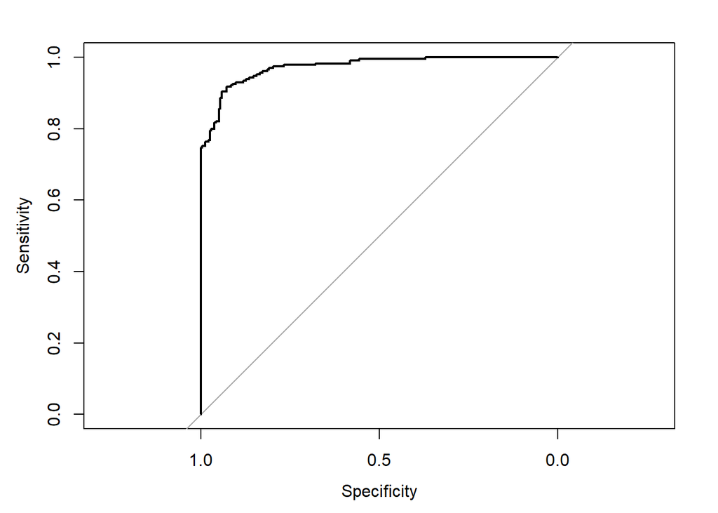

**Confusion Matrix**

targethat 0 1 0 220 22 1 17 207

**Create a binned diagnostic plot of residuals vs prediction** There are definite patterns here, which bear investigating.

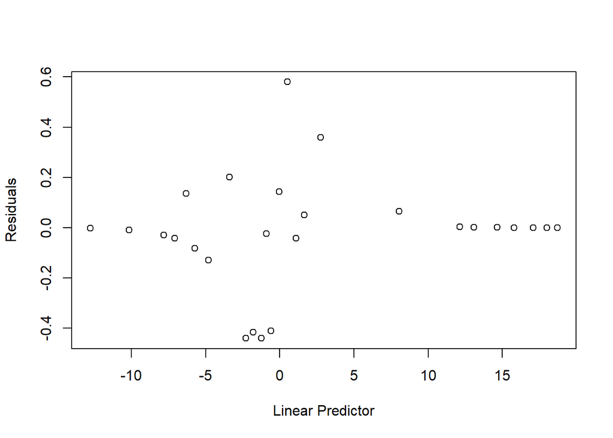

**Plot leverages.**

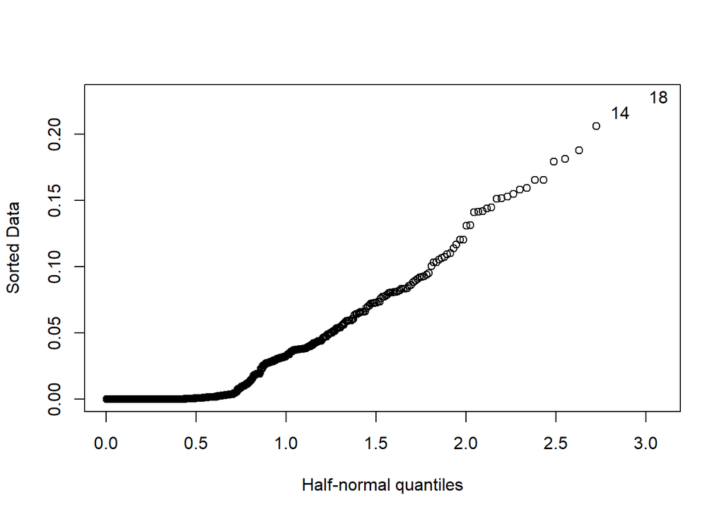

We don’t see any strong outliers with the leverage plot. The points identified (14,18) are essentially in the plot of the line formed, so they are not likely pulling our model in any direction.

**Plot Goodness of fit**

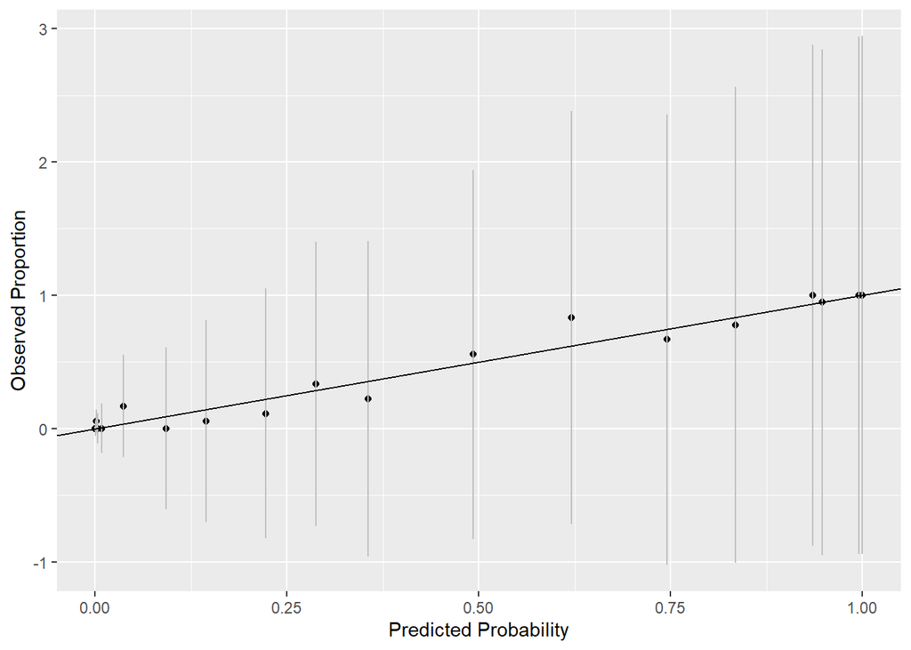

We see that our predictors fall close to the line. (Note to group, need do adjust the min max line)

#### 5.1.1.2 Reduced general model

**ROC Curve**

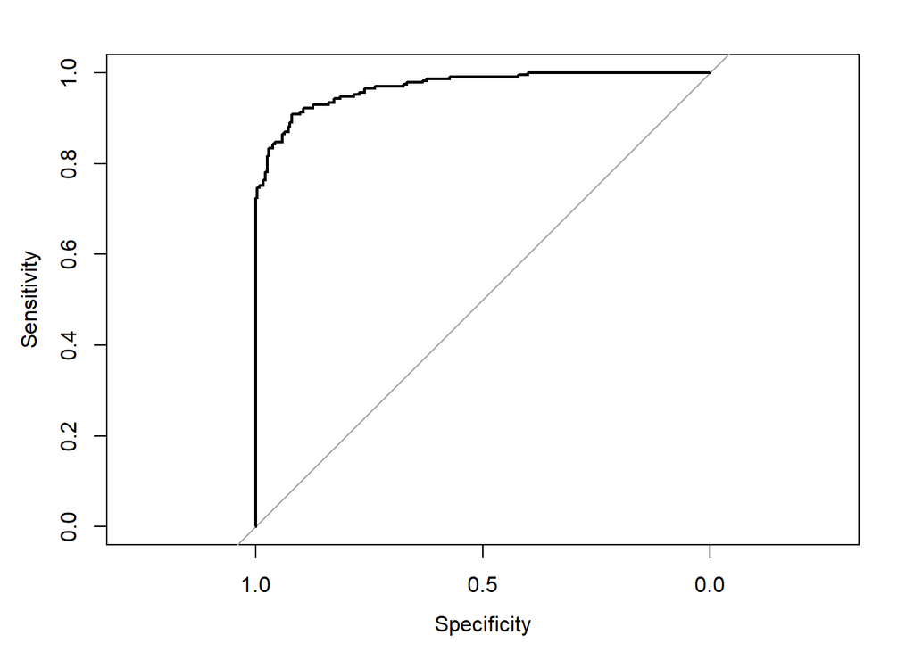

**Confusion Matrix**

targethat 0 1 0 218 22 1 19 207

**Create a binned diagnostic plot of residuals vs prediction** There are definite patterns here, which bear investigating.

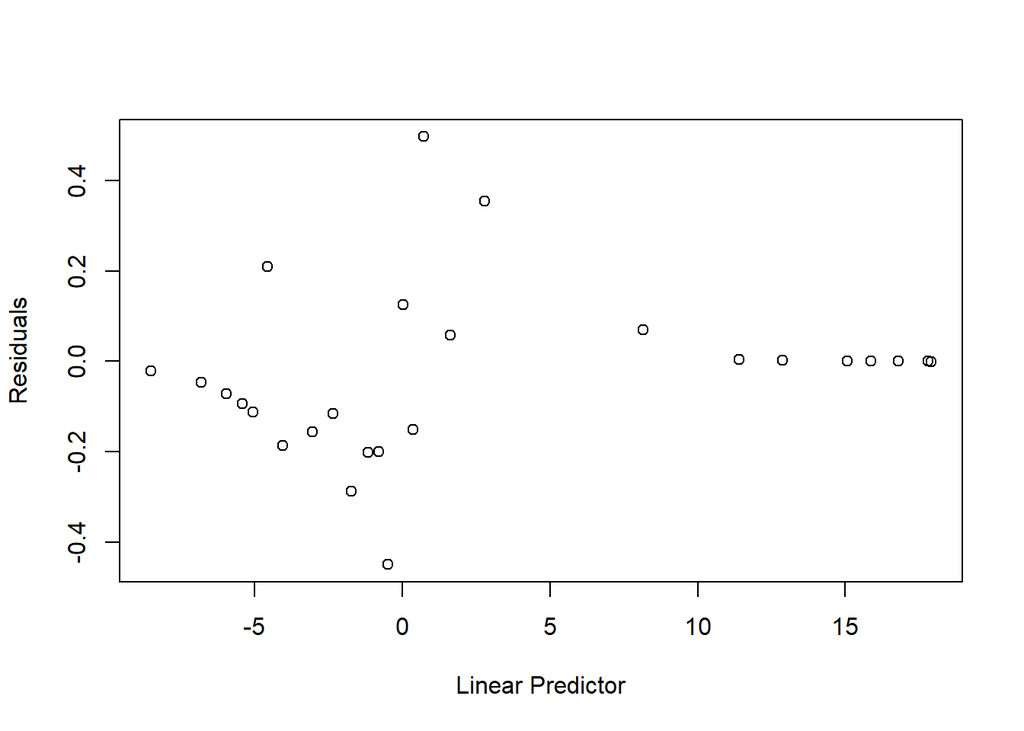

**Plot leverages.**

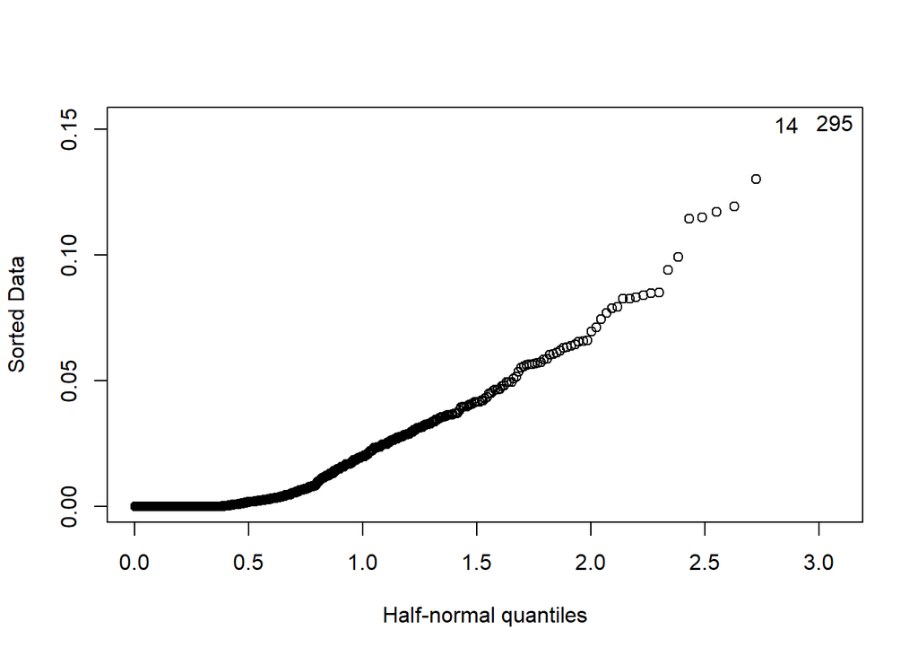

**Plot Goodness of fit**

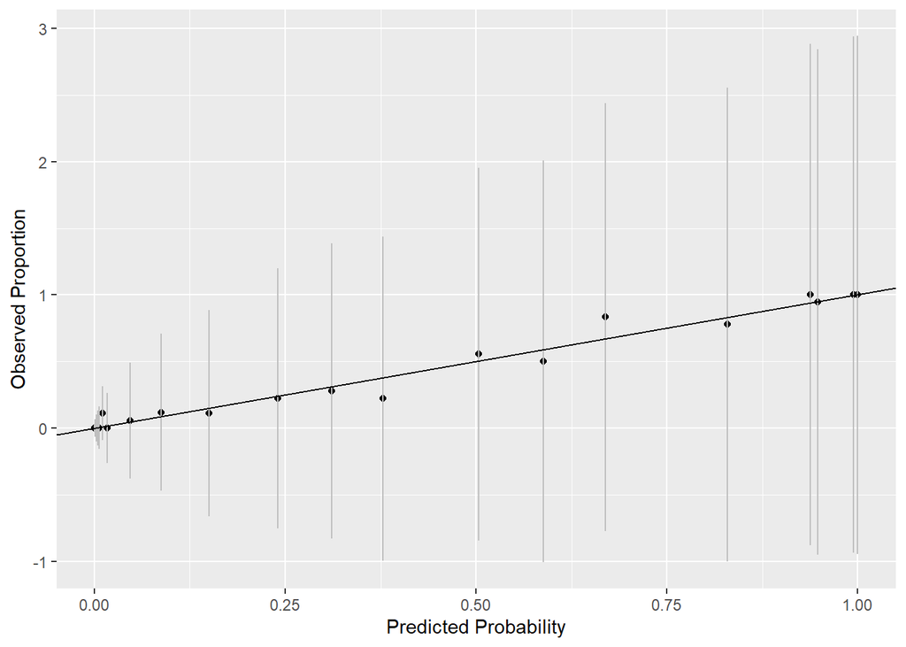

We see that our predictors fall close to the line. (Note to group, need do adjust the min max line)

### 5.1.2 Model 2 - AIC Model

**ROC Curve**

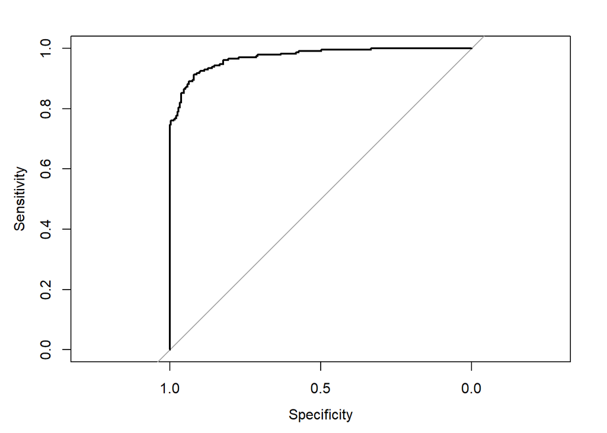

**Confusion Matrix**

targethat 0 1 0 218 22 1 19 207

**Create a binned diagnostic plot of residuals vs prediction**

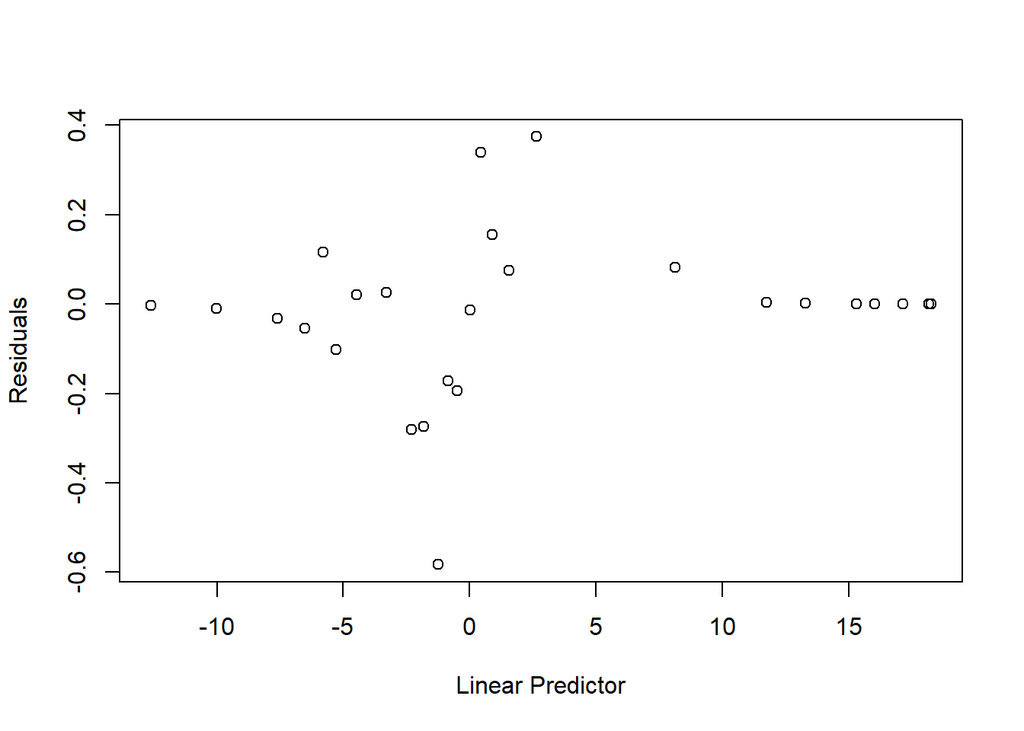

**Plot leverages.**

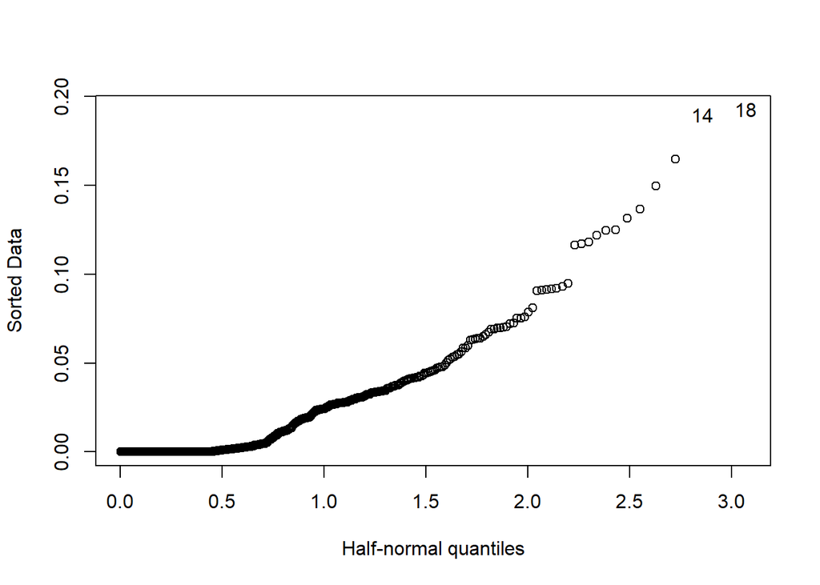

We don’t see any strong outliers with the leverage plot. The points identified (14,18) are essentially in the plot of the line formed, so they are not likely pulling our model in any direction.

**Plot Goodness of fit**

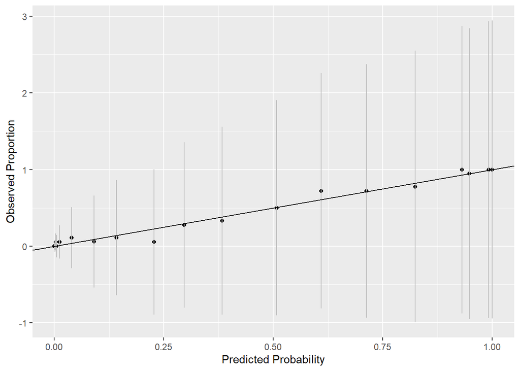

We see that our predictors fall close to the line. (Note to group, need do adjust the min max line)

### 5.1.3 Model 3 - BIC Model

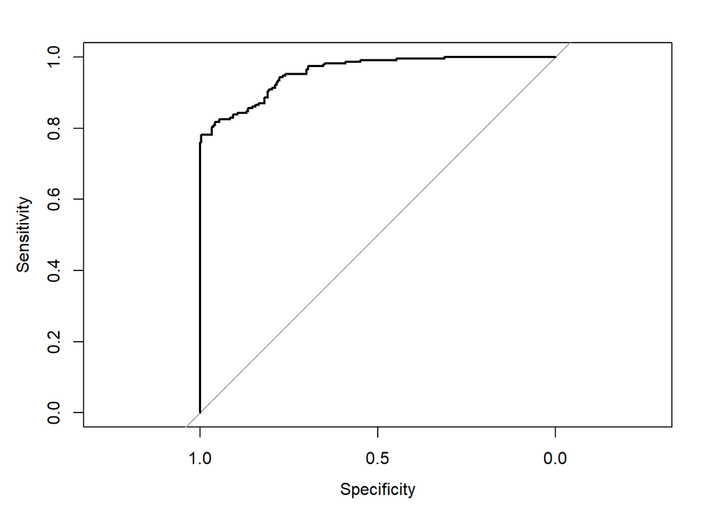

targethat 0 1 0 214 37 1 23 192

The AUC value of 0.96, although high for this model it has the lowest AUC score.

**Create a binned diagnostic plot of residuals vs prediction**

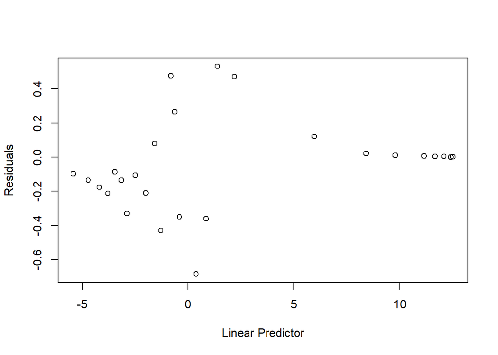

**Plot leverages.**

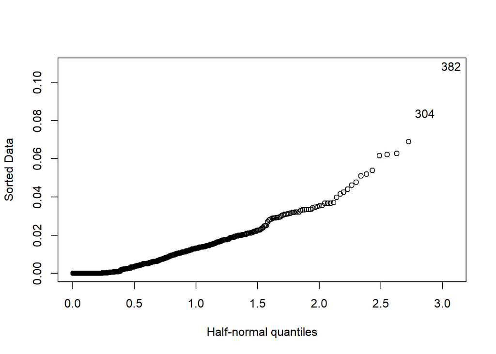

**Plot Goodness of fit**

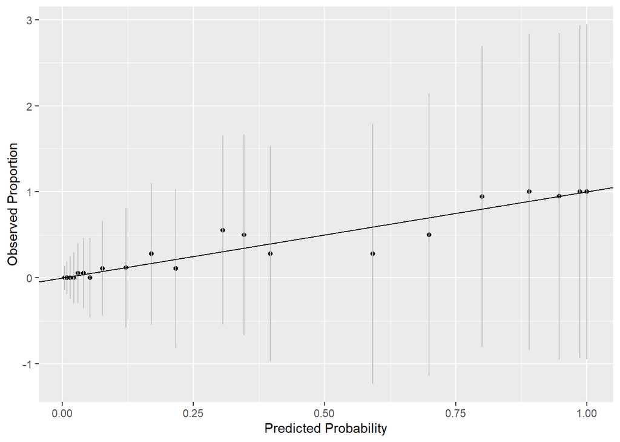

We see that our predictors fall close to the line.

## 5.2 Pick the best regression model

Call: glm(formula = target ~ ., family = binomial(link = “logit”), data = crimeTrain)

Deviance Residuals: Min 1Q Median 3Q Max  
-1.8464 -0.1445 -0.0017 0.0029 3.4665

Coefficients: Estimate Std. Error z value Pr(>|z|)  
(Intercept) -40.822934 6.632913 -6.155 7.53e-10 zn -0.065946 0.034656 -1.903 0.05706 .  
indus -0.064614 0.047622 -1.357 0.17485  
chas 0.910765 0.755546 1.205 0.22803  
nox 49.122297 7.931706 6.193 5.90e-10 rm -0.587488 0.722847 -0.813 0.41637  
age 0.034189 0.013814 2.475 0.01333 *  
dis 0.738660 0.230275 3.208 0.00134 ** rad 0.666366 0.163152 4.084 4.42e-05 *tax -0.006171 0.002955 -2.089 0.03674*  
ptratio 0.402566 0.126627 3.179 0.00148 lstat 0.045869 0.054049 0.849 0.39608  
medv 0.180824 0.068294 2.648 0.00810 ** — Signif. codes: 0 ‘**’ 0.001 ’**’ 0.01 ’’ 0.05 ‘.’ 0.1 ’ ’ 1

(Dispersion parameter for binomial family taken to be 1)

Null deviance: 645.88 on 465 degrees of freedom Residual deviance: 192.05 on 453 degrees of freedom AIC: 218.05

# 6 APPENDIX

**Code used in analysis**

library(ggplot2) library(tidyr) library(MASS) library(psych) library(kableExtra) library(dplyr) library(faraway) library(gridExtra) library(reshape2) library(leaps) library(pROC) library(caret) library(naniar) library(pander) library(pROC) crimeTrain <- read.csv(“crime-training-data_modified.csv”) crimeEval <- read.csv(“crime-evaluation-data_modified.csv”)

## 6.1 OVERVIEW

In this homework assignment, we will explore, analyze and model a data set containing information on crime for various neighborhoods of a major city. Each record has a response variable indicating whether or not the crime rate is above the median crime rate (1) or not (0).

### 6.1.1 Objective:

The objective is to build a binary logistic regression model on the training data set to predict whether the neighborhood will be at risk for high crime levels.

## 6.2 DATA EXPLORATION

### 6.2.1 Data Summary

crimed1 <- describe(crimeTrain, na.rm = F) crimed1$na_count <- sapply(crimeTrain, function(y) sum(length(which(is.na(y))))) crimed1$na_count_perc <- sapply(crimeTrain, function(x) round(sum(is.na(x))/nrow(crimeTrain)*100,1))

colsTrain<-ncol(crimeTrain) colsEval<-ncol(crimeEval) missingCol<-colnames(crimeTrain)[!(colnames(crimeTrain) %in% colnames(crimeEval))]

The dataset consists of two data files: training and evaluation. The training dataset contains 13 columns, while the evaluation dataset contains 12. The evaluation dataset is missing column target which represend our responce variable and defines whether the crime rate is above the median crime rate (1) or not (0). We will start by exploring the training data set since it will be the one used to generate the regression model.

text<-“a test” if(all(apply(crimeTrain,2,function(x) is.numeric(x)))==TRUE) { text<-“all data is numeric” } else { text<-“not all data is numeric” } maxMeanMedianDiff<-round(max(abs(sapply(crimeTrain, median, na.rm = T) - sapply(crimeTrain, mean, na.rm = T))*100/(sapply(crimeTrain, max, na.rm = T)-sapply(crimeTrain, min, na.rm = T))),2)

First we see that all data is numeric. The dataset does contain one dummy variable to identify if the property borders the Charles River (1) or not (0).

nas<-as.data.frame(sapply(crimeTrain, function(x) sum(is.na(x)))) nasp<-as.data.frame(sapply(crimeTrain, function(x) round(sum(is.na(x))/nrow(crimeTrain)*100,1))) colnames(nas)<-c(“name”) maxna<-max(nas) maxnaname<-rownames(nas)[nas$name==maxna] percent<-round(maxna/nrow(crimeTrain)*100,1)

An important aspect of any dataset is to determine how much, if any, data is missing. We look at all the variables to see which if any have missing data. We look at the basic descriptive statistics as well as the missing data and their percentages:

kable(crimed1, “html”, escape = F) %>% kable_styling(bootstrap_options = c(“striped”, “hover”, “condensed”), full_width = T) %>% column_spec(1, bold = T) %>% scroll_box(width = “100%”, height = “500px”) sapply(crimeTrain, function(x) round(sum(is.na(x))/nrow(crimeTrain)*100,1)) vis_miss(crimeTrain) head(crimeTrain)

### 6.2.2 Missing and Invalid Data

No missing data was found in the dataset.

With missing data assessed, we can look into the data in more detail. To visualize this we plot histograms for each data. Several predictors like dist, chas, rad, zn and tax are not normally distributed and noticable outliers.

attach(crimeTrain[,-1]) ggplot(gather(crimeTrain[,-1]), aes(value)) + geom_histogram(bins = 20) + facet_wrap(~key, scales = “free_x”) stripchart(data.frame(scale(crimeTrain)), method =“jitter”, las=2, vertical=TRUE)

### 6.2.3 Mathematical transformations.

crimeTrain_bct <- apply(crimeTrain, 2, BoxCoxTrans) crimeTrain_bct

### 6.2.4 Variable Creation / Removal

corrplot::corrplot(cor(crimeTrain[,1:13]), order = “hclust”, method=‘square’, addrect = 2, tl.col = “black”, tl.cex = .75, na.label = " ")

## 6.3 BUILD MODELS

### 6.3.1 General regression

We start by building a model with all the predictors in the dataset.

m1<-glm(target~.,data=crimeTrain,family=“binomial”(link=“logit”)) summary(m1)

The Summary of this model shows several predictor are not relevant. We build a second model without these predictors.

m1.1<-glm(target~nox+age+dis+rad+tax+ptratio+medv,data=crimeTrain,family=“binomial”(link=“logit”)) summary(m1.1)

1-pchisq(m1.1$deviance,m1.1$df.residual) 1-pchisq(m1$deviance,m1$df.residual)

### 6.3.2 AIC Step Method

Another way of selecting which predictors to use in the model is by calculating the AIC of the model. This metric is similar to the adjusted R-square of a model in that it penalizes models with more predictors over simpler model with few predictors. We use Stepwise function in r to find the lowest AIC with different predictors.

m2 <- step(m1) summary(m2)

This reduces the predictors used in the model to these: zn nox age dis rad tax ptRation medv

The AIC improves marginally from 218.05 (our original general model) to 215.32, but we also benefit by having a simpler model less prone to overfitting.

Also, the predictors in the model now are all signficant (under 0.05 pr level) and all but one under .01 or very significant. Which is much improved over the prior model

### 6.3.3 BIC Method

To determine the number of predictors and which predictors to be used we will use the Bayesian Information Criterion (BIC).

regfit.full <- regsubsets(factor(target) ~ ., data=crimeTrain) par(mfrow = c(1,2)) reg.summary <- summary(regfit.full) plot(reg.summary$bic, xlab="Number of Predictors", ylab="BIC", type="l", main="Subset Selection Using BIC") BIC_num <- which.min(reg.summary$bic) points(BIC_num, reg.summary$bic[BIC_num], col=“red”, cex=2, pch=20) plot(regfit.full, scale=“bic”, main=“Predictors vs. BIC”) par(mfrow = c(1,1))

The plot on the right shows that the number of predictors with the lowest BIC are `nox` , `age`, `rad`, and `medv`. We will use those predictors to build the next model

m3 <- glm(target ~ nox + age + rad + medv, family=binomial, data = crimeTrain) crimeTrain$predicted_m3<- predict(m3, crimeTrain, type='response') crimeTrain$target_m3$target <- ifelse(crimeTrain$predicted_m3>0.5, 1, 0) pander::pander(summary(m3))

Forward Selection Method using some BoxCox transformed independent variables:

{r echo=FALSE, warning=FALSE, message=FALSE, results=“asis”} m4 <- step(glm(target~1, data=crimeTrain), direction = “forward”, scope = ~zn + I(log(indus)) + I(sqrt(chas)) + I(nox^-1) + I(log(rm)) + I(age^2) + I(dis^-.5) + rad + I(tax^-1) + I(ptratio^2) + lstat + medv) summary(m4)

## 6.4 SELECT MODELS

Compare Model Statistics

### 6.4.1 Model 1 - General Model

Complete general model

#### 6.4.1.1 **ROC Curve**

The ROC Curve helps measure true positives and true negative. A high AUC or area under the curve tells us the model is predicting well.

targethat<-predict(m1,type=“response”) g<-roc(target~targethat,data=crimeTrain) plot(g)

The AUC value of 0.96, tells us this model predicted values are acurate.

#### 6.4.1.2 **Confusion Matrix**

targethat[targethat<0.5]<-0 targethat[targethat>=0.5]<-1 table(targethat,crimeTrain$target)

#### 6.4.1.3 **Create a binned diagnostic plot of residuals vs prediction**

There are definite patterns here, which bear investigating.

crimeMut <- mutate(crimeTrain, Residuals = residuals(m1), linPred = predict(m1)) grpCrime <- group_by(crimeMut, cut(linPred, breaks=unique(quantile(linPred, (0:25/26))))) diagCrime <- summarise(grpCrime, Residuals = mean(Residuals), linPred = mean(linPred)) plot(Residuals ~ linPred, data = diagCrime, xlab=“Linear Predictor”)

#### 6.4.1.4 **Plot leverages.**

halfnorm(hatvalues(m1))

We don’t see any strong outliers with the leverage plot. The points identified (14,18) are essentially in the plot of the line formed, so they are not likely pulling our model in any direction.

#### 6.4.1.5 **Plot Goodness of fit**

linPred <- predict(m1) crimeMut <- mutate(crimeTrain, predProb = predict(m1, type = “response”)) grpCrime <- group_by(crimeMut, cut(linPred, breaks = unique(quantile(linPred, (0:25)/26))))

hlDf <- summarise(grpCrime, y= sum(target), pPred=mean(predProb), count = n()) hlDf <- mutate(hlDf, se.fit=sqrt(pPred * (1-(pPred)/count))) ggplot(hlDf,aes(x=pPred,y=y/count,ymin=y/count-2*se.fit,ymax=y/count+2*se.fit)) + geom_point()+geom_linerange(color=grey(0.75))+geom_abline(intercept=0,slope=1) + xlab(“Predicted Probability”) + ylab(“Observed Proportion”)

We see that our predictors fall close to the line. (Note to group, need do adjust the min max line)

### 6.4.2 Reduced general model

#### 6.4.2.1 **ROC Curve**

targethat<-predict(m1.1,type=“response”) g<-roc(target~targethat,data=crimeTrain) plot(g)

This model also show a high AUC value of 0.96. This tells us predicted values are acurate, although slightly lower.

#### 6.4.2.2 **Confusion Matrix**

targethat[targethat<0.5]<-0 targethat[targethat>=0.5]<-1 table(targethat,crimeTrain$target)

#### 6.4.2.3 **Create a binned diagnostic plot of residuals vs prediction**

There are definite patterns here, which bear investigating.

crimeMut <- mutate(crimeTrain, Residuals = residuals(m1.1), linPred = predict(m1.1)) grpCrime <- group_by(crimeMut, cut(linPred, breaks=unique(quantile(linPred, (0:25/26))))) diagCrime <- summarise(grpCrime, Residuals = mean(Residuals), linPred = mean(linPred)) plot(Residuals ~ linPred, data = diagCrime, xlab=“Linear Predictor”)

#### 6.4.2.4 **Plot leverages.**

halfnorm(hatvalues(m1.1))

#### 6.4.2.5 **Plot Goodness of fit**

linPred <- predict(m1.1) crimeMut <- mutate(crimeTrain, predProb = predict(m1.1, type = “response”)) grpCrime <- group_by(crimeMut, cut(linPred, breaks = unique(quantile(linPred, (0:25)/26))))

hlDf <- summarise(grpCrime, y= sum(target), pPred=mean(predProb), count = n()) hlDf <- mutate(hlDf, se.fit=sqrt(pPred * (1-(pPred)/count))) ggplot(hlDf,aes(x=pPred,y=y/count,ymin=y/count-2*se.fit,ymax=y/count+2*se.fit)) + geom_point()+geom_linerange(color=grey(0.75))+geom_abline(intercept=0,slope=1) + xlab(“Predicted Probability”) + ylab(“Observed Proportion”)

We see that our predictors fall close to the line. (Note to group, need do adjust the min max line)

### 6.4.3 Model 2 - AIC Model

#### 6.4.3.1 **ROC Curve**

targethat<-predict(m2,type=“response”) g<-roc(target~targethat,data=crimeTrain) plot(g)

The AUC value of 0.96, tells us this model predicted values are acurate.

#### 6.4.3.2 **Confusion Matrix**

targethat[targethat<0.5]<-0 targethat[targethat>=0.5]<-1 table(targethat,crimeTrain$target)

#### 6.4.3.3 **Create a binned diagnostic plot of residuals vs prediction**

crimeMut <- mutate(crimeTrain, Residuals = residuals(m2), linPred = predict(m2)) grpCrime <- group_by(crimeMut, cut(linPred, breaks=unique(quantile(linPred, (0:25/26))))) diagCrime <- summarise(grpCrime, Residuals = mean(Residuals), linPred = mean(linPred)) plot(Residuals ~ linPred, data = diagCrime, xlab=“Linear Predictor”)

#### 6.4.3.4 **Plot leverages.**

halfnorm(hatvalues(m2))

We don’t see any strong outliers with the leverage plot. The points identified (14,18) are essentially in the plot of the line formed, so they are not likely pulling our model in any direction.

#### 6.4.3.5 **Plot Goodness of fit**

linPred <- predict(m2) crimeMut <- mutate(crimeTrain, predProb = predict(m2, type = “response”)) grpCrime <- group_by(crimeMut, cut(linPred, breaks = unique(quantile(linPred, (0:25)/26))))

hlDf <- summarise(grpCrime, y= sum(target), pPred=mean(predProb), count = n()) hlDf <- mutate(hlDf, se.fit=sqrt(pPred * (1-(pPred)/count))) ggplot(hlDf,aes(x=pPred,y=y/count,ymin=y/count-2*se.fit,ymax=y/count+2*se.fit)) + geom_point()+geom_linerange(color=grey(0.75))+geom_abline(intercept=0,slope=1) + xlab(“Predicted Probability”) + ylab(“Observed Proportion”)

We see that our predictors fall close to the line. (Note to group, need do adjust the min max line)

### 6.4.4 Model 3 - BIC Model

targethat<-predict(m3,type=“response”) g<-roc(target~targethat,data=crimeTrain) plot(g) targethat[targethat<0.5]<-0 targethat[targethat>=0.5]<-1 table(targethat,crimeTrain$target)

The AUC value of 0.96, although high for this model it has the lowest AUC score.

#### 6.4.4.1 **Create a binned diagnostic plot of residuals vs prediction**

crimeMut <- mutate(crimeTrain, Residuals = residuals(m3), linPred = predict(m3)) grpCrime <- group_by(crimeMut, cut(linPred, breaks=unique(quantile(linPred, (0:25/26))))) diagCrime <- summarise(grpCrime, Residuals = mean(Residuals), linPred = mean(linPred)) plot(Residuals ~ linPred, data = diagCrime, xlab=“Linear Predictor”)

#### 6.4.4.2 **Plot leverages.**

halfnorm(hatvalues(m3))

#### 6.4.4.3 **Plot Goodness of fit**

linPred <- predict(m3) crimeMut <- mutate(crimeTrain, predProb = predict(m3, type = “response”)) grpCrime <- group_by(crimeMut, cut(linPred, breaks = unique(quantile(linPred, (0:25)/26))))

hlDf <- summarise(grpCrime, y= sum(target), pPred=mean(predProb), count = n()) hlDf <- mutate(hlDf, se.fit=sqrt(pPred * (1-(pPred)/count))) ggplot(hlDf,aes(x=pPred,y=y/count,ymin=y/count-2*se.fit,ymax=y/count+2*se.fit)) + geom_point()+geom_linerange(color=grey(0.75))+geom_abline(intercept=0,slope=1) + xlab(“Predicted Probability”) + ylab(“Observed Proportion”)

We see that our predictors fall close to the line.

Pick the best regression model

m1AIC <- AIC(m1) m1BIC <- BIC(m1) m2AIC <- AIC(m2) m2BIC <- BIC(m2) m3AIC <- AIC(m3) m3BIC <- BIC(m3) m4AIC <- AIC(m4) m4BIC <- BIC(m4) summary(m1)